# Project #2

Trennon, Jessie, Jose

5/4/2020

Project Number 2 (due for your group by 1:30pm on May 6th, the end of the final exam period for the class). Working on the same teams as last time, working with the same data as last time, and working with the same response variable as last time, do the following steps:

```r
library(tidyverse)
```

```r
library(leaps)
library(dplyr)
library(corrplot)
library(readxl)
library(ggplot2)
library(GGally)
library(DT)
library(caTools)
library(glmnet)
library(leaps)
housing <- read_excel("Housing.xlsx")
attach(housing)
set.seed(1)
```

# a.

Consider the model that you arrived at in the previous project as the first candidate model.

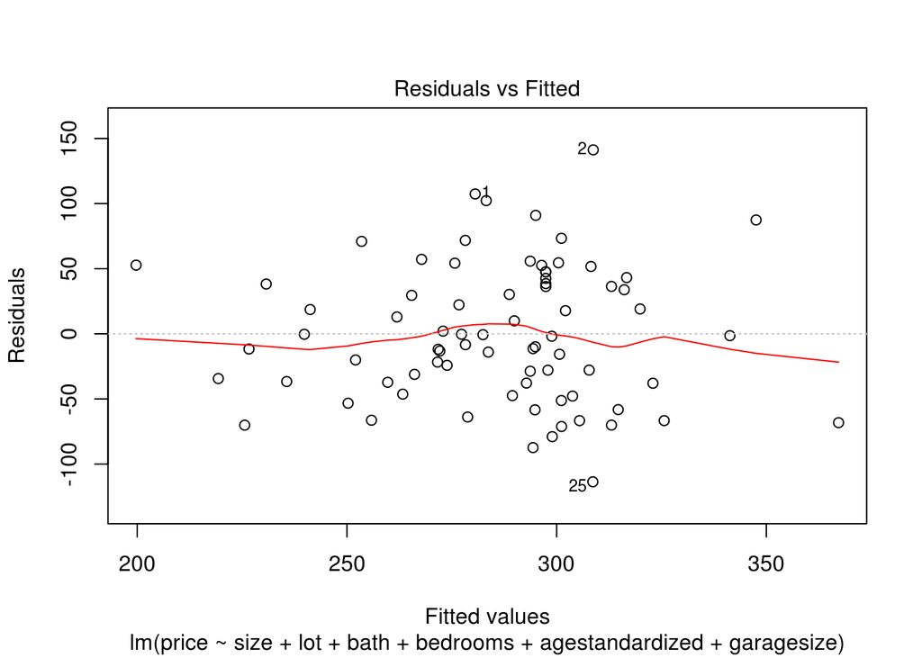

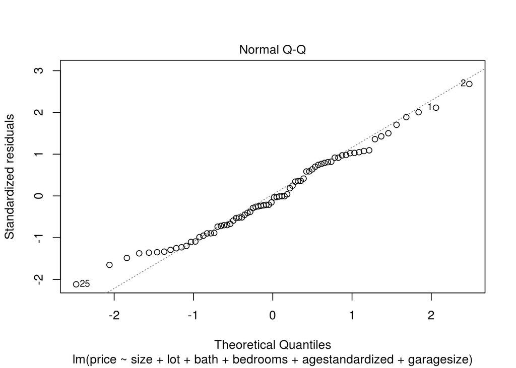

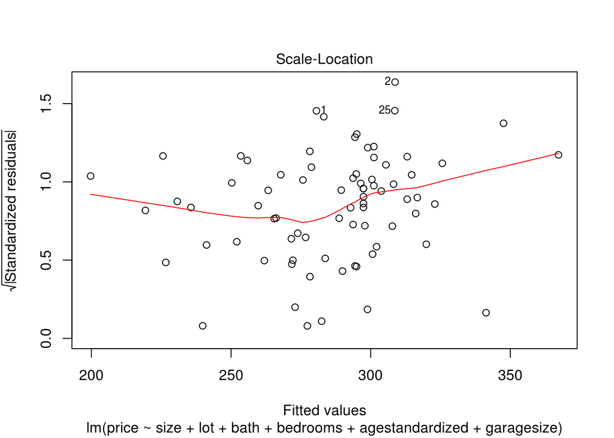

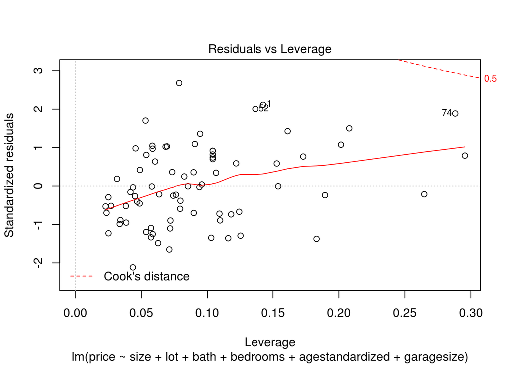

```r
finalmod <-lm(price ~ size + lot + bath + bedrooms + agestandardized + garagesize, data = housing)
plot(finalmod)
```

```r
summary(finalmod)
```

```
##
## Call:
## lm(formula = price ~ size + lot + bath + bedrooms + agestandardized +
##     garagesize, data = housing)
##
## Residuals:
##     Min      1Q  Median      3Q     Max
## -113.63  -37.84   -5.10   39.59  141.28
##
## Coefficients:
##                 Estimate Std. Error t value Pr(>|t|)
## (Intercept)      181.482     64.574   2.810  0.00643 **
## size              49.079     35.733   1.373  0.17405
## lot                5.291      4.186   1.264  0.21051
## bath              17.330     13.665   1.268  0.20899
## bedrooms         -23.167     10.643  -2.177  0.03292 *
## agestandardized   -3.870      3.531  -1.096  0.27682
## garagesize        17.811     10.650   1.672  0.09898 .
## ---
## Signif. codes:  0 '***' 0.001 '**' 0.01 '*' 0.05 '.' 0.1 ' ' 1
##
## Residual standard error: 54.9 on 69 degrees of freedom
## Multiple R-squared:  0.2383, Adjusted R-squared:  0.1721
## F-statistic: 3.598 on 6 and 69 DF,  p-value: 0.003672
```

# b.

Create a second candidate model by using regsubsets over the entire data set. You can decide whether you prefer overall selection, forward selection, or backward selection, and you can decide which statistic you will use to determine the best model from the regsubsets process. Just conduct a justifiable model selection process and report the predictors in your final model.

```r
regfit.full <- regsubsets(price ~ id + size + lot + bath + bedrooms + agestandardized + garagesize + status + elem, data = housing, nvmax = 14)
reg.summary <- summary(regfit.full)
names(reg.summary)
```

```
## [1] "which"  "rsq"    "rss"    "adjr2"  "cp"     "bic"    "outmat" "obj"
```

```r
reg.summary$bic
```

```
##  [1]  -1.7863476 -10.3081110 -15.2600323 -19.7220814 -22.4837938 -22.6105510
##  [7] -20.3906504 -17.6757586 -15.0643496 -11.6418283  -7.7234094  -3.6261882
## [13]   0.5383984   4.8059017
```

```r
par(mfrow = c(2, 2))
plot(reg.summary$rss, xlab = "Number of Variables", ylab = "RSS")

plot(reg.summary$adjr2, xlab = "Number of Variables", ylab = "Adjusted RSq")
which.max(reg.summary$adjr2)
```

```
## [1] 9
```

```r
points(9, reg.summary$adjr2[9], col = "red", cex = 2, pch = 20)

plot(reg.summary$cp, xlab = "Number of Variables", ylab = "Cp")
which.min(reg.summary$cp)
```

```
## [1] 6
```

```r
points(6, reg.summary$cp[6], col = "red", cex = 2, pch = 20)

plot(reg.summary$bic, xlab = "Number of Variables", ylab = "BIC")
which.min(reg.summary$bic)
```

```
## [1] 6
```

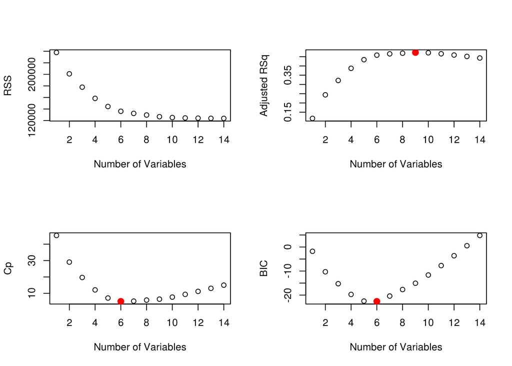

```r
points(6, reg.summary$bic[6], col = "red", cex = 2, pch = 20)
```

```r
coef(regfit.full, 6)
```

```
## (Intercept)        size         lot    bedrooms   statussld  elemedison
##  127.556047   85.475310    9.995031  -16.004639  -34.907872   79.665432
##  elemharris
##   54.392695
```

# c.

Create a training/test split of the data by which roughly half of the 76 observations are training data and half are test data.

```r
set.seed(1)
train <- sample(c(TRUE, FALSE), nrow(housing), rep = TRUE)
test <- (!train)
test
```

```
##  [1] FALSE FALSE  TRUE  TRUE FALSE  TRUE  TRUE  TRUE  TRUE FALSE FALSE FALSE
## [13]  TRUE FALSE  TRUE FALSE  TRUE  TRUE FALSE  TRUE  TRUE FALSE  TRUE FALSE
## [25] FALSE FALSE FALSE FALSE  TRUE FALSE FALSE  TRUE FALSE FALSE  TRUE  TRUE
## [37]  TRUE FALSE  TRUE FALSE  TRUE  TRUE  TRUE  TRUE  TRUE  TRUE FALSE FALSE
## [49]  TRUE  TRUE FALSE  TRUE FALSE FALSE FALSE FALSE FALSE  TRUE  TRUE FALSE
## [61]  TRUE FALSE FALSE FALSE  TRUE FALSE FALSE  TRUE FALSE  TRUE FALSE  TRUE
## [73] FALSE FALSE FALSE  TRUE
```

# d.

Now use regsubsets over only the training data to determine the number of predictors that should be in your final model. Then use regsubsets over the entire data set with the determined number of variables to determine your third candidate model.

```r
set.seed(1)

regfit.best <- regsubsets(price ~ id + size + lot + bath + bedrooms + agestandardized + garagesize + status + elem, data = housing[train, ], nvmax = 14)

test.mat <- model.matrix(price ~ id + size + lot + bath + bedrooms + agestandardized + garagesize + status + elem, data = housing[test, ])

val.errors <- rep(NA, 14)
for(i in 1: 14){
  coefi = coef(regfit.best, id = i)
  pred = test.mat[, names(coefi)]%*%coefi
  val.errors[i] = mean((housing$price[test] - pred)^2)
}

val.errors
```

```
##  [1] 3291.975 3655.479 3713.480 3044.076 3366.699 2911.513 2484.384 2650.321
##  [9] 3520.744 3099.686 2942.913 2954.630 2939.537 2948.394
```

```r
which.min(val.errors)
```

```
## [1] 7
```

```r
regfit.best2 <- regsubsets(price ~ id + size + lot + bath + bedrooms + agestandardized + garagesize + status + elem, data = housing[train, ], nvmax = 7)

coef(regfit.best2, 7)
```

```
##     (Intercept)            size             lot        bedrooms agestandardized
##      116.816303       86.751449       13.789252      -20.382807        9.226705
##       statussld      elemedison      elemharris
##      -22.258492      119.587051       43.724871
```

# e.

Next, use either Ridge Regression or Lasso Regression with the training data, and use cross validation via the cv.glmnet function to determine the best λ value. The model from this step with the best λ value will be your fourth candidate model.

```r
#library(glmnet)
set.seed(1)
train.mat <- model.matrix(price ~ ., data = housing[train,])
test.mat <- model.matrix(price ~ ., data = housing[test,])
grid <- 10 ^ seq(4, -2, length = 100)
ridge.mod <- glmnet(train.mat, housing$price[train], alpha = 0, lambda = grid, thresh = 1e-12)
ridge.cv <- cv.glmnet(train.mat, housing$price[train], alpha = 0, lambda = grid, thresh = 1e-12)
ridge.bestlam <- ridge.cv$lambda.min
ridge.bestlam
```

```
## [1] 65.79332
```

```r
min(ridge.cv$lambda)
```

```
## [1] 0.01
```

```r
ridge.pred <- predict(ridge.mod, s = 16.29751, newx = test.mat)
mean((ridge.pred - housing$price[test])^2)
```

```
## [1] 1871.207
```

```r
out = glmnet(train.mat <- model.matrix(price ~ ., data = housing), housing$price, alpha = 0)

ridge.final <- predict(out, type = "coefficients", s = ridge.bestlam)[1:17,]
ridge.final
```

```
##     (Intercept)     (Intercept)              id            size             lot
##    128.86766873      0.00000000     -0.02321362     27.43317017      4.28202556
##            bath        bedrooms       yearbuilt agestandardized      garagesize
##      6.10229778     -7.39977992      0.04601017      0.46002637      8.58346870
##       statuspen       statussld       elemcrest        elemedge      elemedison
##      2.16564369    -12.23638115     -0.82845567    -10.42567388     27.80419213
##      elemharris      elemparker
##     15.06341898    -15.59797103
```

We found that our best lambda from the ridge regression is 65.79332.